# Week 08 Functions Homework

Author

Timothy Li

Published

October 18, 2026

## For this week, I created two functions. One converts British Pounds to US Dollars and the other plots data on the cost of Cappuccinos with the wage of baristas.

### The first step is loading in the libraries

```r
### Load in Libraries #####

library(tidyverse)
library(here)
```

### The next step is reading in our data.

This data was found through the Tidytuesday repository and is titled the Cappuccino Index. For this assignment, I will only be using the Cafe data set but wanted to include the cappuccino_index so you could see what type of information is included in that.

```r
##### Read in Data #####

cafe = read_csv("https://raw.githubusercontent.com/rfordatascience/tidytuesday/main/data/2026/2026-09-08/cafe.csv")
cappuccino_index = read_csv("https://raw.githubusercontent.com/rfordatascience/tidytuesday/main/data/2026/2026-09-08/cappuccino_index.csv")

head(cafe)
```

```
# A tibble: 6 × 10
  country city  urban suburban rural hourly_wage_gbp price_gbp original_currency
  <chr>   <chr> <lgl> <lgl>    <lgl>           <dbl>     <dbl> <chr>
1 Denmark Cope… TRUE  FALSE    FALSE           16.0      10.3  DKK - Danish Kro…
2 China   Shen… TRUE  FALSE    FALSE            3.29      9.44 CNY - Yuan Renmi…
3 USA     West… FALSE TRUE     FALSE           13.2       8.89 USD - US dollar
4 Switze… St. … FALSE FALSE    TRUE            24.5       8.26 CHF - Swiss Franc
5 Denmark Cope… TRUE  FALSE    FALSE           16.0       7.45 DKK - Danish Kro…
6 Singap… Sing… TRUE  FALSE    FALSE           11.2       6.89 SGD - Singapore …
# ℹ 2 more variables: price <dbl>, hourly_wage <dbl>
```

```r
head(cappuccino_index)
```

```
# A tibble: 6 × 6
  country     index     n minutes seconds index_as_time
  <chr>       <dbl> <dbl>   <dbl>   <dbl> <chr>
1 Australia    10.1   171      10       4 10:04
2 Italy        11.9    15      11      51 11:51
3 New Zealand  12.7    35      12      44 12:44
4 Switzerland  14.4    18      14      24 14:24
5 Netherlands  14.9    73      14      51 14:51
6 Puerto Rico  14.9     1      14      53 14:53
```

### The third step is cleaning up the data for only US cafes.

```r
USA_cafe <- cafe |>
  drop_na() |>
  filter(country == "USA")
```

### The fourth step is writing a code to convert the British Pound to US Dollars.

You’ll notice in the Cafe data set that it already includes both the British Pound and US Dollar price. However, you can use the following function to make this calculation. It is based on the exchange rate at the time of producing this document.

```r
gbp_to_usd <- function(amount_gbp) {
  amount_usd <- amount_gbp * 1.31 # 1.31 was the current exchange rate at time of creating this
  return(amount_usd)
}
```

##### Example 1: 4.63 Pounds

```r
gbp_to_usd(4.63) # For a coffee shop in urban Los Angeles
```

```
[1] 6.0653
```

##### Example 2: 4.82 Pounds

```r
gbp_to_usd(4.82) # For a coffee shop in New York City
```

```
[1] 6.3142
```

### The fifth step is creating my function for plotting the data

```r
my_plot <- function(data = USA_cafe, x, y, lines = TRUE) { # Set Data to USA_cafe in function so don't need to specify later

  if (lines == TRUE) { # If lines == TRUE, geom_smooth() is added on plot
    ggplot(data, aes(x = {{x}}, y = {{y}})) + # Pass columns as arguments
      geom_point(size = 2, color = "#4B3832") + # Dark cappuccino color hex code
      geom_smooth(method = "lm", linewidth = 1.5, alpha = .3, color = "blue") +
      theme_bw()
  } else { # No geom_smooth()
    ggplot(data, aes(x = {{x}}, y = {{y}})) + # Pass columns as arguments
      geom_point(size = 2, color = "#4B3832") +
      theme_bw()
  }
}
```

### The sixth step is running the function to get some simple graphs!

For the first one, I compared the hourly wage of baristas to the price of a small cappuccino in British Pounds. In the second one, I compared the hourly wage of baristas to the price of a cappuccino in US Dollars.

You’ll notice in both cases I set lines = TRUE because I wanted it to be easier to see if there was a relationship between these variables. I put the option in their though if someone wanted to see just the scatter plot.

##### Example 1

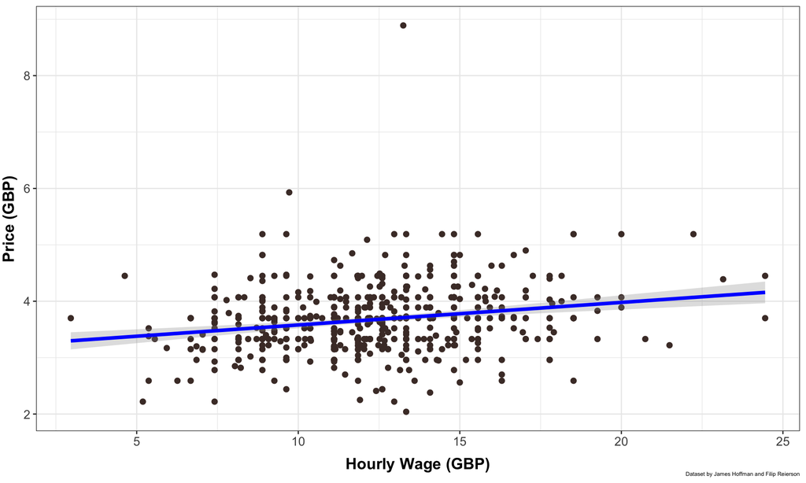

Figure 1: The Relationship Between the Hourly Wage of Baristas and the Price of a Cappuccino in British Pounds

```r
my_plot(x = hourly_wage_gbp, y = price_gbp, lines = TRUE) +
  labs(x = "Hourly Wage (GBP)", y = "Price (GBP)",
       caption = "Dataset by James Hoffman and Filip Reierson") + # From tidytuesday
  theme( # Adjust theme just like creating a plot directly
    axis.title.x = element_text(size = 14, face = "bold", vjust = -1),
    axis.title.y = element_text(size = 14, face = "bold", vjust = 2),
    plot.caption = element_text(size = 5),
    axis.text.x = element_text(size = 11),
    axis.text.y = element_text(size = 11),
  )

ggsave(here("Week_08", "Outputs", "HW08-fig-coffee-GBP.png"), width = 10, height = 6)
```

##### Example

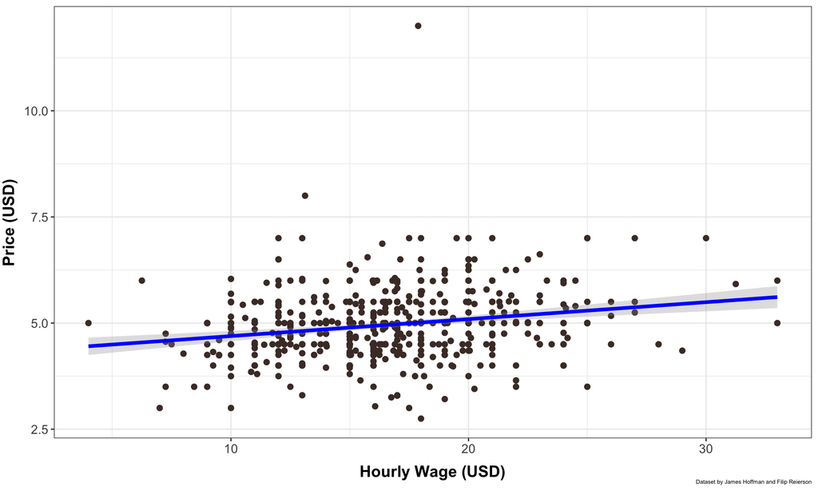

Figure 2: The Relationship Between the Hourly Wage of Baristas and the Price of a Cappuccino in US Dollars

```r
my_plot(x = hourly_wage, y = price, lines = TRUE) +
  labs(x = "Hourly Wage (USD)", y = "Price (USD)",
       caption = "Dataset by James Hoffman and Filip Reierson") + # From tidytuesday
  theme( # Adjust theme just like creating a plot directly
    axis.title.x = element_text(size = 14, face = "bold", vjust = -1),
    axis.title.y = element_text(size = 14, face = "bold", vjust = 2),
    plot.caption = element_text(size = 5),
    axis.text.x = element_text(size = 11),
    axis.text.y = element_text(size = 11),
  )

ggsave(here("Week_08", "Outputs", "HW08-fig-coffee-USD.png"), width = 10, height = 6)
```

As you can see, there is a relatively weak positive relationship between the two. I’d expect that in places where the hourly wage is higher, the price of a small cappuccino would be higher. That’s kind of what we see.